# Homework 7

Ethan Thibault

2/28/2018

This is my homework 6 where I am making a fake data set to explore one of my hypotheses.

I am going to tackle the hypothesis that the various haplotypes of GI will confer differences in stress tolerance (in this case, specifically electrolyte leakage that is a proxy for cold tolerance).

```r
setwd("~/Documents/UVM_2018/BIO381")
library(ggplot2)

# Here I am going to create a function that will create a normal distribution based on parameters I gathered from the literature about my experiment

dataCreate <- function(mean1=10,mean2=40,mean3=60,n1=10,n2=10,n3=10,sd1=10,sd2=10,sd3=10){
  mydf <- data.frame(GI1=rnorm(mean=mean1,n=n1,sd=sd1), GI2=rnorm(mean=mean2,n=n2,sd=sd2), GI3=rnorm(mean=mean3,n=n3,sd=sd3))
  return(mydf)
}
myDF <- dataCreate()
myDF
```

```
##           GI1      GI2      GI3
## 1  10.4495802 34.99315 53.17229
## 2  17.1860738 17.64945 52.35026
## 3   4.9946447 47.82814 65.07998
## 4   6.9335787 39.47535 41.59967
## 5   8.1698481 37.42558 68.67404
## 6   0.4008407 30.33430 65.19352
## 7   4.2267416 36.90113 66.50713
## 8  11.7750175 51.28836 46.84420
## 9   2.5594725 34.21494 39.62014
## 10 19.4389288 47.85900 69.60923
```

```r
str(myDF)
```

```
## 'data.frame':    10 obs. of  3 variables:
##  $ GI1: num  10.45 17.19 4.99 6.93 8.17 ...
##  $ GI2: num  35 17.6 47.8 39.5 37.4 ...
##  $ GI3: num  53.2 52.4 65.1 41.6 68.7 ...
```

```r
# Convert dataframe into a usable form for ANOVA

library(reshape2)
myDF2 <- melt(myDF)
myDF2
```

```
##    variable      value
## 1       GI1 10.4495802
## 2       GI1 17.1860738
## 3       GI1  4.9946447
## 4       GI1  6.9335787
## 5       GI1  8.1698481
## 6       GI1  0.4008407
## 7       GI1  4.2267416
## 8       GI1 11.7750175
## 9       GI1  2.5594725
## 10      GI1 19.4389288
## 11      GI2 34.9931482
## 12      GI2 17.6494465
## 13      GI2 47.8281428
## 14      GI2 39.4753509
```

[output cut: 16 more lines]

```r
# Now I am going to run an ANOVA on the dataframe to see if there is significance

ANO <- aov(value~variable,data=myDF2)
print(ANO)
```

```
## Call:
##    aov(formula = value ~ variable, data = myDF2)
##
## Terms:
##                  variable Residuals
## Sum of Squares  11811.605  2409.994
## Deg. of Freedom         2        27
##
## Residual standard error: 9.4477
## Estimated effects may be unbalanced
```

```r
summary(ANO)[[1]][["Pr(>F)"]][1]
```

```
## [1] 3.912112e-11
```

```r
str(summary(ANO))
```

```
## List of 1
##  $ :Classes 'anova' and 'data.frame':    2 obs. of  5 variables:
##   ..$ Df     : num [1:2] 2 27
##   ..$ Sum Sq : num [1:2] 11812 2410
##   ..$ Mean Sq: num [1:2] 5905.8 89.3
##   ..$ F value: num [1:2] 66.2 NA
##   ..$ Pr(>F) : num [1:2] 3.91e-11 NA
##  - attr(*, "class")= chr [1:2] "summary.aov" "listof"
```

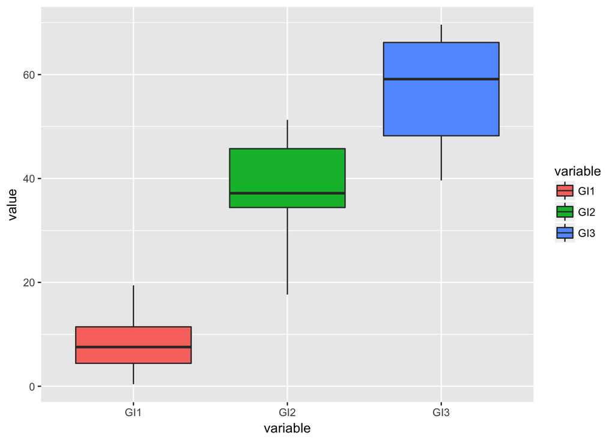

```r
# Plot the data to visualize

ANOPlot <- ggplot(data=myDF2,aes(x=variable,y=value,fill=variable)) +
                    geom_boxplot()

print(ANOPlot)
```

Here are the ANOVA results from a few iterations of my function:

```r
#             Df Sum Sq Mean Sq F value   Pr(>F)
# variable     2  14277    7139   44.52 2.83e-09 ***
# Residuals   27   4330     160
# ---
# Signif. codes:  0 ‘***’ 0.001 ‘**’ 0.01 ‘*’ 0.05 ‘.’ 0.1 ‘ ’ 1

#             Df Sum Sq Mean Sq F value   Pr(>F)
# variable     2  11847    5923   60.38 1.08e-10 ***
# Residuals   27   2649      98
# ---
# Signif. codes:  0 ‘***’ 0.001 ‘**’ 0.01 ‘*’ 0.05 ‘.’ 0.1 ‘ ’ 1

#             Df Sum Sq Mean Sq F value   Pr(>F)
# variable     2  10688    5344   33.06 5.52e-08 ***
# Residuals   27   4365     162
# ---
# Signif. codes:  0 ‘***’ 0.001 ‘**’ 0.01 ‘*’ 0.05 ‘.’ 0.1 ‘ ’ 1
```

We are really interested in whether of not the different GI transformants had different percentages of electrolyte leakage and so all I care is that there is as least a significant difference between two treatments. All of these have strong statistical p-values and I ran them with the large end of the errors seen in the literature, so I am going to try running this with decreased sample sizes similar to the literature (2-4 replicates per group)

```r
myDF <- dataCreate(n1=3,n2=3,n3=3)
myDF
```

```
##        GI1      GI2      GI3
## 1 26.47676 45.85397 64.61911
## 2 20.93722 39.66305 29.24219
## 3 13.49567 25.76292 56.28844
```

```r
str(myDF)
```

```
## 'data.frame':    3 obs. of  3 variables:
##  $ GI1: num  26.5 20.9 13.5
##  $ GI2: num  45.9 39.7 25.8
##  $ GI3: num  64.6 29.2 56.3
```

```r
# Convert dataframe into a usable form for ANOVA

library(reshape2)
myDF2 <- melt(myDF)
myDF2
```

```
##   variable    value
## 1      GI1 26.47676
## 2      GI1 20.93722
## 3      GI1 13.49567
## 4      GI2 45.85397
## 5      GI2 39.66305
## 6      GI2 25.76292
## 7      GI3 64.61911
## 8      GI3 29.24219
## 9      GI3 56.28844
```

```r
# Now I am going to run an ANOVA on the dataframe to see if there is significance

ANO <- aov(value~variable,data=myDF2)
print(ANO)
```

```
## Call:
##    aov(formula = value ~ variable, data = myDF2)
##
## Terms:
##                  variable Residuals
## Sum of Squares  1334.6470  980.7296
## Deg. of Freedom         2         6
##
## Residual standard error: 12.78495
## Estimated effects may be unbalanced
```

```r
summary(ANO)
```

```
##             Df Sum Sq Mean Sq F value Pr(>F)
## variable     2 1334.6   667.3   4.083  0.076 .
## Residuals    6  980.7   163.5
## ---
## Signif. codes:  0 '***' 0.001 '**' 0.01 '*' 0.05 '.' 0.1 ' ' 1
```

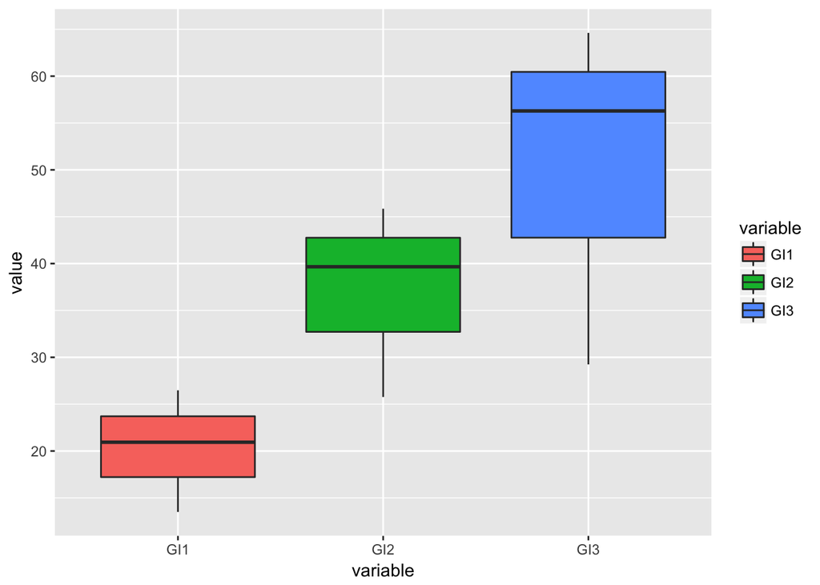

```r
# Plot the data to visualize

ANOPlot <- ggplot(data=myDF2,aes(x=variable,y=value,fill=variable)) +
                    geom_boxplot()
print(ANOPlot)
```

Here are a few summaries of the output ANOVAs:

```r
#             Df Sum Sq Mean Sq F value  Pr(>F)
# variable     2   2263  1131.5   20.39 0.00211 **
# Residuals    6    333    55.5
# ---
# Signif. codes:  0 ‘***’ 0.001 ‘**’ 0.01 ‘*’ 0.05 ‘.’ 0.1 ‘ ’ 1
#
#             Df Sum Sq Mean Sq F value   Pr(>F)
# variable     2   3660  1829.9   63.31 9.26e-05 ***
# Residuals    6    173    28.9
# ---
# Signif. codes:  0 ‘***’ 0.001 ‘**’ 0.01 ‘*’ 0.05 ‘.’ 0.1 ‘ ’ 1
#
#             Df Sum Sq Mean Sq F value  Pr(>F)
# variable     2   4906  2453.2   14.67 0.00489 **
# Residuals    6   1003   167.2
# ---
# Signif. codes:  0 ‘***’ 0.001 ‘**’ 0.01 ‘*’ 0.05 ‘.’ 0.1 ‘ ’ 1
```

I am still seeing significant p-values, but they are not quite as strong. I will now try with 3 and 10 replicates per treatment, but with means that are closer together.

```r
myDF <- dataCreate(n1=3,n2=3,n3=3,mean1 = 30,mean2 = 40,mean3 = 50)
myDF
```

```
##        GI1      GI2      GI3
## 1 36.06258 34.72906 60.14467
## 2 43.15184 21.11052 53.74603
## 3 27.25495 43.84256 48.08804
```

```r
str(myDF)
```

```
## 'data.frame':    3 obs. of  3 variables:
##  $ GI1: num  36.1 43.2 27.3
##  $ GI2: num  34.7 21.1 43.8
##  $ GI3: num  60.1 53.7 48.1
```

```r
# Convert dataframe into a usable form for ANOVA

library(reshape2)
myDF2 <- melt(myDF)
myDF2
```

```
##   variable    value
## 1      GI1 36.06258
## 2      GI1 43.15184
## 3      GI1 27.25495
## 4      GI2 34.72906
## 5      GI2 21.11052
## 6      GI2 43.84256
## 7      GI3 60.14467
## 8      GI3 53.74603
## 9      GI3 48.08804
```

```r
# Now I am going to run an ANOVA on the dataframe to see if there is significance

ANO <- aov(value~variable,data=myDF2)
print(ANO)
```

```
## Call:
##    aov(formula = value ~ variable, data = myDF2)
##
## Terms:
##                 variable Residuals
## Sum of Squares  778.6912  461.3759
## Deg. of Freedom        2         6
##
## Residual standard error: 8.769035
## Estimated effects may be unbalanced
```

```r
summary(ANO)
```

```
##             Df Sum Sq Mean Sq F value Pr(>F)
## variable     2  778.7   389.3   5.063 0.0515 .
## Residuals    6  461.4    76.9
## ---
## Signif. codes:  0 '***' 0.001 '**' 0.01 '*' 0.05 '.' 0.1 ' ' 1
```

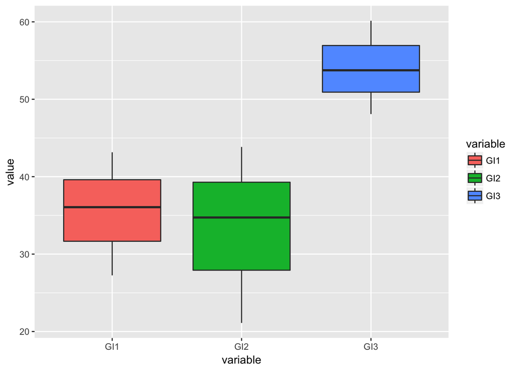

```r
# Plot the data to visualize

ANOPlot <- ggplot(data=myDF2,aes(x=variable,y=value,fill=variable)) +
                    geom_boxplot()
print(ANOPlot)
```

Here are a few summaries of the output ANOVAs:

```r
#             Df Sum Sq Mean Sq F value Pr(>F)
# variable     2 1329.9   664.9   5.731 0.0406 *
# Residuals    6  696.2   116.0
# ---
# Signif. codes:  0 ‘***’ 0.001 ‘**’ 0.01 ‘*’ 0.05 ‘.’ 0.1 ‘ ’ 1
#
#             Df Sum Sq Mean Sq F value Pr(>F)
# variable     2  525.0  262.49   3.632 0.0926 .
# Residuals    6  433.7   72.28
# ---
# Signif. codes:  0 ‘***’ 0.001 ‘**’ 0.01 ‘*’ 0.05 ‘.’ 0.1 ‘ ’ 1
#
#             Df Sum Sq Mean Sq F value Pr(>F)
# variable     2  404.8  202.38   3.555 0.0959 .
# Residuals    6  341.6   56.93
# ---
# Signif. codes:  0 ‘***’ 0.001 ‘**’ 0.01 ‘*’ 0.05 ‘.’ 0.1 ‘ ’ 1
```

Here I am changing the means and using 10 for the replicates

```r
myDF <- dataCreate(n1=10,n2=10,n3=10,mean1 = 30,mean2 = 40,mean3 = 50)
myDF
```

```
##         GI1      GI2      GI3
## 1  56.49734 34.28414 44.42949
## 2  34.82601 49.16317 47.05859
## 3  24.13494 31.37518 56.78807
## 4  33.31829 33.01777 38.34964
## 5  33.26960 46.63568 45.09001
## 6  41.31030 40.59366 41.55634
## 7  23.71931 55.50947 58.92034
## 8  22.80913 24.01497 53.43694
## 9  42.90097 38.29111 44.61449
## 10 18.59627 27.52485 50.28768
```

```r
str(myDF)
```

```
## 'data.frame':    10 obs. of  3 variables:
##  $ GI1: num  56.5 34.8 24.1 33.3 33.3 ...
##  $ GI2: num  34.3 49.2 31.4 33 46.6 ...
##  $ GI3: num  44.4 47.1 56.8 38.3 45.1 ...
```

```r
# Convert dataframe into a usable form for ANOVA

library(reshape2)
myDF2 <- melt(myDF)
myDF2
```

```
##    variable    value
## 1       GI1 56.49734
## 2       GI1 34.82601
## 3       GI1 24.13494
## 4       GI1 33.31829
## 5       GI1 33.26960
## 6       GI1 41.31030
## 7       GI1 23.71931
## 8       GI1 22.80913
## 9       GI1 42.90097
## 10      GI1 18.59627
## 11      GI2 34.28414
## 12      GI2 49.16317
## 13      GI2 31.37518
## 14      GI2 33.01777
```

[output cut: 16 more lines]

```r
# Now I am going to run an ANOVA on the dataframe to see if there is significance

ANO <- aov(value~variable,data=myDF2)
print(ANO)
```

```
## Call:
##    aov(formula = value ~ variable, data = myDF2)
##
## Terms:
##                 variable Residuals
## Sum of Squares  1155.787  2498.434
## Deg. of Freedom        2        27
##
## Residual standard error: 9.619491
## Estimated effects may be unbalanced
```

```r
summary(ANO)
```

```
##             Df Sum Sq Mean Sq F value Pr(>F)
## variable     2   1156   577.9   6.245 0.0059 **
## Residuals   27   2498    92.5
## ---
## Signif. codes:  0 '***' 0.001 '**' 0.01 '*' 0.05 '.' 0.1 ' ' 1
```

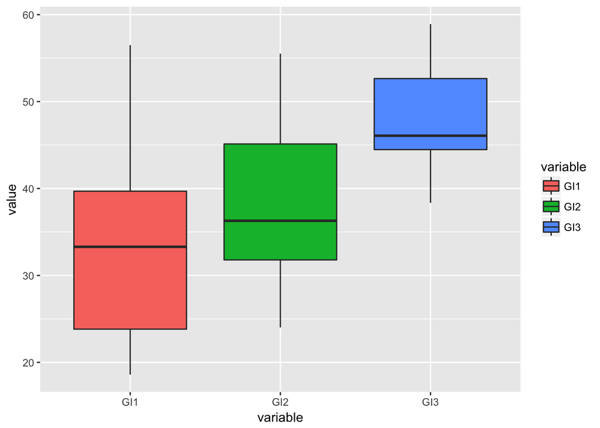

```r
# Plot the data to visualize

ANOPlot <- ggplot(data=myDF2,aes(x=variable,y=value,fill=variable)) +
                    geom_boxplot()
print(ANOPlot)
```

Here are a few summaries of the output ANOVAs:

```r
#             Df Sum Sq Mean Sq F value   Pr(>F)
# variable     2   3359  1679.5    14.4 5.54e-05 ***
# Residuals   27   3148   116.6
# ---
# Signif. codes:  0 ‘***’ 0.001 ‘**’ 0.01 ‘*’ 0.05 ‘.’ 0.1 ‘ ’ 1
#
#             Df Sum Sq Mean Sq F value   Pr(>F)
# variable     2   2228  1114.1      16 2.61e-05 ***
# Residuals   27   1880    69.6
# ---
# Signif. codes:  0 ‘***’ 0.001 ‘**’ 0.01 ‘*’ 0.05 ‘.’ 0.1 ‘ ’ 1
#
#             Df Sum Sq Mean Sq F value Pr(>F)
# variable     2  603.5  301.73   3.474 0.0454 *
# Residuals   27 2345.2   86.86
# ---
# Signif. codes:  0 ‘***’ 0.001 ‘**’ 0.01 ‘*’ 0.05 ‘.’ 0.1 ‘ ’ 1
```

What this tells me:

I could use 3 replicates and get significant data if the means are fairly spread apart. Due to the way that we are doing this experiment, I am more inclined to think that the means will be closer together so to maximize the chance of getting significant data, I should use 10 replicates. This is ten per temperature treatment which would end up being around 110 plants (testing 10 different temperatures for electrolyte leakage).

I think I will check other replicate numbers between 3 and 10 to hopefully decrease the number of replicates because it will be difficult to generate these mutants and as of now they produce very few seeds.

This is the start of the second lab day working on this assignment.

```r
myDF <- dataCreate(n1=5,n2=5,n3=5,mean1 = 30,mean2 = 40,mean3 = 50)
myDF
```

```
##        GI1      GI2      GI3
## 1 23.19940 46.67342 42.12474
## 2 19.93204 40.55389 56.08764
## 3 37.13518 52.68133 67.48108
## 4 10.32900 55.52336 59.91548
## 5 21.58162 47.14921 39.40785
```

```r
str(myDF)
```

```
## 'data.frame':    5 obs. of  3 variables:
##  $ GI1: num  23.2 19.9 37.1 10.3 21.6
##  $ GI2: num  46.7 40.6 52.7 55.5 47.1
##  $ GI3: num  42.1 56.1 67.5 59.9 39.4
```

```r
# Convert dataframe into a usable form for ANOVA

library(reshape2)
myDF2 <- melt(myDF)
myDF2
```

```
##    variable    value
## 1       GI1 23.19940
## 2       GI1 19.93204
## 3       GI1 37.13518
## 4       GI1 10.32900
## 5       GI1 21.58162
## 6       GI2 46.67342
## 7       GI2 40.55389
## 8       GI2 52.68133
## 9       GI2 55.52336
## 10      GI2 47.14921
## 11      GI3 42.12474
## 12      GI3 56.08764
## 13      GI3 67.48108
## 14      GI3 59.91548
## 15      GI3 39.40785
```

```r
# Now I am going to run an ANOVA on the dataframe to see if there is significance

ANO <- aov(value~variable,data=myDF2)
print(ANO)
```

```
## Call:
##    aov(formula = value ~ variable, data = myDF2)
##
## Terms:
##                 variable Residuals
## Sum of Squares  2724.565  1075.417
## Deg. of Freedom        2        12
##
## Residual standard error: 9.466681
## Estimated effects may be unbalanced
```

```r
summary(ANO)
```

```
##             Df Sum Sq Mean Sq F value   Pr(>F)
## variable     2   2725  1362.3    15.2 0.000514 ***
## Residuals   12   1075    89.6
## ---
## Signif. codes:  0 '***' 0.001 '**' 0.01 '*' 0.05 '.' 0.1 ' ' 1
```

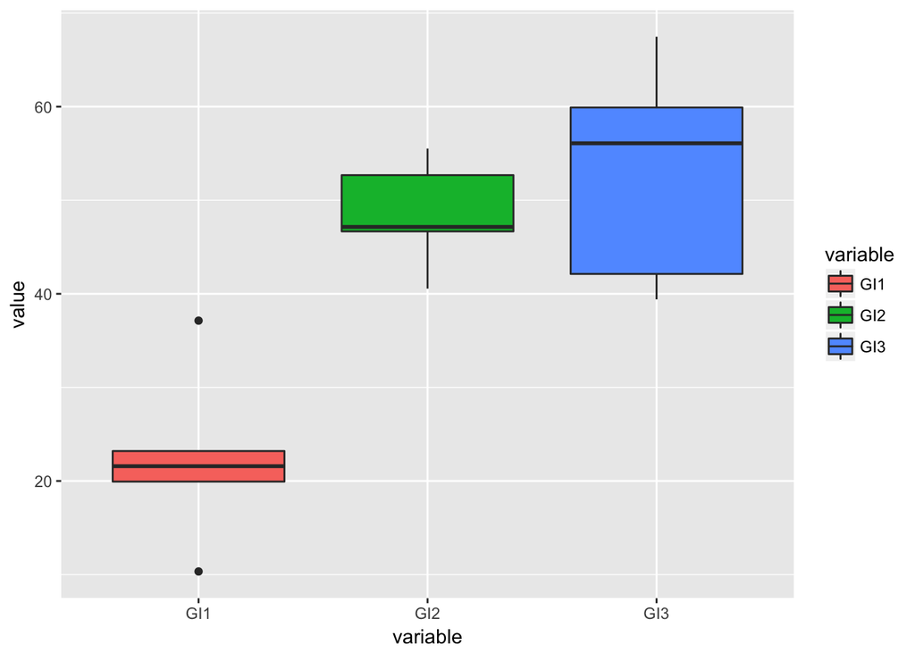

```r
# Plot the data to visualize

ANOPlot <- ggplot(data=myDF2,aes(x=variable,y=value,fill=variable)) +
                    geom_boxplot()
print(ANOPlot)
```

Here are a few summaries of the ANOVAs

```r
#             Df Sum Sq Mean Sq F value Pr(>F)
# variable     2  236.6  118.32   1.246  0.322
# Residuals   12 1139.8   94.98
#
#             Df Sum Sq Mean Sq F value Pr(>F)
# variable     2  441.4   220.7   1.531  0.256
# Residuals   12 1729.7   144.1
#
#             Df Sum Sq Mean Sq F value  Pr(>F)
# variable     2   1599   799.4   8.084 0.00598 **
# Residuals   12   1187    98.9
# ---
# Signif. codes:  0 ‘***’ 0.001 ‘**’ 0.01 ‘*’ 0.05 ‘.’ 0.1 ‘ ’ 1
```

That time, only one was significant.

Now let me try 7 individuals.

```r
myDF <- dataCreate(n1=7,n2=7,n3=7,mean1 = 30,mean2 = 40,mean3 = 50)
myDF
```

```
##         GI1      GI2      GI3
## 1 14.029805 31.02731 52.62621
## 2  5.201615 45.47177 41.26532
## 3 31.629278 38.34613 59.81337
## 4 34.783419 26.10674 43.98751
## 5 38.769208 28.62969 64.62910
## 6 20.603965 46.12955 49.24035
## 7 33.889754 38.01542 50.81079
```

```r
str(myDF)
```

```
## 'data.frame':    7 obs. of  3 variables:
##  $ GI1: num  14 5.2 31.6 34.8 38.8 ...
##  $ GI2: num  31 45.5 38.3 26.1 28.6 ...
##  $ GI3: num  52.6 41.3 59.8 44 64.6 ...
```

```r
# Convert dataframe into a usable form for ANOVA

library(reshape2)
myDF2 <- melt(myDF)
myDF2
```

```
##    variable     value
## 1       GI1 14.029805
## 2       GI1  5.201615
## 3       GI1 31.629278
## 4       GI1 34.783419
## 5       GI1 38.769208
## 6       GI1 20.603965
## 7       GI1 33.889754
## 8       GI2 31.027309
## 9       GI2 45.471769
## 10      GI2 38.346133
## 11      GI2 26.106737
## 12      GI2 28.629686
## 13      GI2 46.129550
## 14      GI2 38.015424
## 15      GI3 52.626215
## 16      GI3 41.265323
## 17      GI3 59.813370
## 18      GI3 43.987509
## 19      GI3 64.629096
## 20      GI3 49.240351
## 21      GI3 50.810787
```

```r
# Now I am going to run an ANOVA on the dataframe to see if there is significance

ANO <- aov(value~variable,data=myDF2)
print(ANO)
```

```
## Call:
##    aov(formula = value ~ variable, data = myDF2)
##
## Terms:
##                 variable Residuals
## Sum of Squares  2431.503  1725.155
## Deg. of Freedom        2        18
##
## Residual standard error: 9.789891
## Estimated effects may be unbalanced
```

```r
summary(ANO)
```

```
##             Df Sum Sq Mean Sq F value   Pr(>F)
## variable     2   2432  1215.8   12.69 0.000365 ***
## Residuals   18   1725    95.8
## ---
## Signif. codes:  0 '***' 0.001 '**' 0.01 '*' 0.05 '.' 0.1 ' ' 1
```

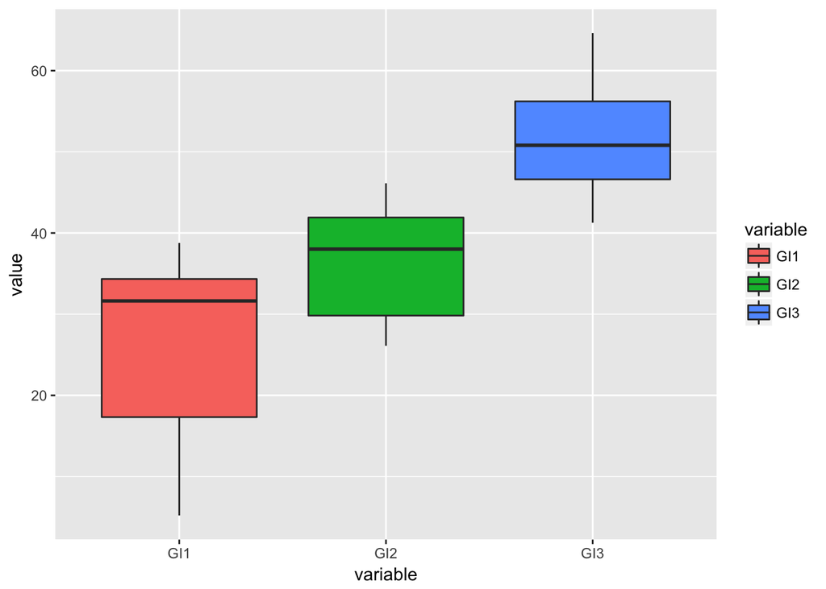

```r
# Plot the data to visualize

ANOPlot <- ggplot(data=myDF2,aes(x=variable,y=value,fill=variable)) +
                    geom_boxplot()
print(ANOPlot)
```

Here are a few summary results from the ANOVAs

```r
#             Df Sum Sq Mean Sq F value  Pr(>F)
# variable     2   1174   586.8   8.887 0.00207 **
# Residuals   18   1188    66.0
# ---
# Signif. codes:  0 ‘***’ 0.001 ‘**’ 0.01 ‘*’ 0.05 ‘.’ 0.1 ‘ ’ 1
#
#             Df Sum Sq Mean Sq F value Pr(>F)
# variable     2  858.8   429.4   4.979  0.019 *
# Residuals   18 1552.3    86.2
# ---
# Signif. codes:  0 ‘***’ 0.001 ‘**’ 0.01 ‘*’ 0.05 ‘.’ 0.1 ‘ ’ 1
#
#             Df Sum Sq Mean Sq F value  Pr(>F)
# variable     2   1156   577.7   9.183 0.00178 **
# Residuals   18   1132    62.9
# ---
# Signif. codes:  0 ‘***’ 0.001 ‘**’ 0.01 ‘*’ 0.05 ‘.’ 0.1 ‘ ’ 1
```

All of those are significant so seven individuals per treatment seem reasonable if the means are 10 percentage points apart and have sd’s of 10.

Here is the ANOVA function

```r
###################################################
# FUNCTION: ANOVA
# Runs an ANOVA on a dataframe of values
# input: dataframe
# output: summary of ANOVA
ANOVA <- function(data=as.data.frame(matrix(data=1:12,nrow=4))){
  library(reshape2)
  myDF2 <- melt(myDF)
  ANO <- aov(value~variable,data=myDF2)
  return(summary(ANO))
}
###################################################
ANOVA()
```

```
##             Df Sum Sq Mean Sq F value   Pr(>F)
## variable     2   2432  1215.8   12.69 0.000365 ***
## Residuals   18   1725    95.8
## ---
## Signif. codes:  0 '***' 0.001 '**' 0.01 '*' 0.05 '.' 0.1 ' ' 1
```

```r
# First run both functions
dataCreate <- function(mean1=10,mean2=40,mean3=60,n1=10,n2=10,n3=10,sd1=10,sd2=10,sd3=10){
  mydf <- data.frame(GI1=rnorm(mean=mean1,n=n1,sd=sd1), GI2=rnorm(mean=mean2,n=n2,sd=sd2), GI3=rnorm(mean=mean3,n=n3,sd=sd3))
  return(mydf)
}
ANOVA <- function(data=as.data.frame(matrix(data=1:12,nrow=4))){
  library(reshape2)
  suppressMessages(expr = myDF2 <- melt(data))
  ANO <- aov(value~variable,data=myDF2)
  return(summary(ANO))
}

###################################################
# FUNCTION: simulation
# Creates 10 distributions of data, runs and ANOVA on each
# input: parameters for distributions and the number of simulations
# output: summary of ANOVAs
simulation <- function(mean1=10,mean2=40,mean3=60,n1=10,n2=10,n3=10,sd1=10,sd2=10,sd3=10,nsim=1000){
  results <- vector()
  for(i in 1:nsim){
    mydf <- dataCreate(mean1=mean1,mean2=mean2,mean3=mean3,n1=n1,n2=n2,n3=n3,sd1=sd1,sd2=sd2,sd3=sd3)
    anosum <- ANOVA(data=mydf)
    anosumpval <- anosum[[1]][["Pr(>F)"]][1]
    results <- c(results, anosumpval)
  }
  sigpval <- sum(results <= 0.05)
  return(sigpval)
}
###################################################
```

```r
simulation(n1=5,n2=5,n3=5,mean1 = 30,mean2 = 40,mean3 = 50)
```

```
## [1] 685
```